# Football analytics (FIFA 2020)

# Content

Different Analysis for FIFA 2020 players database provided by Kaggle (https://www.kaggle.com/stefanoleone992/fifa-20-complete-player-dataset?select=players_20.csv).

```python
# import pcakages and Load Data
import pandas as pd
import matplotlib.pyplot as plt
import numpy as np
import seaborn as sb
%matplotlib inline
data = pd.read_excel('players_20.xlsx')
```

```python
#Information of Data
data.info()
```

```
<class 'pandas.core.frame.DataFrame'>
RangeIndex: 18278 entries, 0 to 18277
Columns: 104 entries, sofifa_id to rb
dtypes: datetime64[ns](2), float64(16), int64(45), object(41)
memory usage: 14.5+ MB
```

### Data Cleaning

```python
#Remove some unnecessary data as the current version is 14.5+ MB
data.drop(['player_url', 'short_name', 'dob', 'real_face','weak_foot','preferred_foot','player_tags','team_jersey_number','loaned_from','joined','contract_valid_until'], axis=1, inplace = True)
data.drop(['ls', 'st', 'rs', 'lw','lf','cf','rf','rw','lam','cam','ram'], axis=1, inplace = True)
```

```python
#New Check for data info
data.info()
```

```
<class 'pandas.core.frame.DataFrame'>
RangeIndex: 18278 entries, 0 to 18277
Data columns (total 82 columns):
 #   Column                      Non-Null Count  Dtype
---  ------                      --------------  -----
 0   sofifa_id                   18278 non-null  int64
 1   long_name                   18278 non-null  object
 2   age                         18278 non-null  int64
 3   height_cm                   18278 non-null  int64
 4   weight_kg                   18278 non-null  int64
 5   nationality                 18278 non-null  object
 6   club                        18278 non-null  object
 7   overall                     18278 non-null  int64
 8   potential                   18278 non-null  int64
 9   value_eur                   18278 non-null  int64
```

[output cut: 74 more lines]

```python
#duplicated values
data.duplicated().sum()
```

```
0
```

```python
#First 10 rows in the data
data.head(10)
```

|  | sofifa_id | long_name | age | height_cm | weight_kg | nationality | club | overall | potential | value_eur | ... | lwb | ldm | cdm | rdm | rwb | lb | lcb | cb | rcb | rb |
| --- | --- | --- | --- | --- | --- | --- | --- | --- | --- | --- | --- | --- | --- | --- | --- | --- | --- | --- | --- | --- | --- |
| 0 | 158023 | Lionel Andrés Messi Cuccittini | 32 | 170 | 72 | Argentina | FC Barcelona | 94 | 94 | 95500000 | ... | 68+2 | 66+2 | 66+2 | 66+2 | 68+2 | 63+2 | 52+2 | 52+2 | 52+2 | 63+2 |
| 1 | 20801 | Cristiano Ronaldo dos Santos Aveiro | 34 | 187 | 83 | Portugal | Juventus | 93 | 93 | 58500000 | ... | 65+3 | 61+3 | 61+3 | 61+3 | 65+3 | 61+3 | 53+3 | 53+3 | 53+3 | 61+3 |
| 2 | 190871 | Neymar da Silva Santos Junior | 27 | 175 | 68 | Brazil | Paris Saint-Germain | 92 | 92 | 105500000 | ... | 66+3 | 61+3 | 61+3 | 61+3 | 66+3 | 61+3 | 46+3 | 46+3 | 46+3 | 61+3 |
| 3 | 200389 | Jan Oblak | 26 | 188 | 87 | Slovenia | Atlético Madrid | 91 | 93 | 77500000 | ... | NaN | NaN | NaN | NaN | NaN | NaN | NaN | NaN | NaN | NaN |
| 4 | 183277 | Eden Hazard | 28 | 175 | 74 | Belgium | Real Madrid | 91 | 91 | 90000000 | ... | 66+3 | 63+3 | 63+3 | 63+3 | 66+3 | 61+3 | 49+3 | 49+3 | 49+3 | 61+3 |
| 5 | 192985 | Kevin De Bruyne | 28 | 181 | 70 | Belgium | Manchester City | 91 | 91 | 90000000 | ... | 77+3 | 77+3 | 77+3 | 77+3 | 77+3 | 73+3 | 66+3 | 66+3 | 66+3 | 73+3 |
| 6 | 192448 | Marc-André ter Stegen | 27 | 187 | 85 | Germany | FC Barcelona | 90 | 93 | 67500000 | ... | NaN | NaN | NaN | NaN | NaN | NaN | NaN | NaN | NaN | NaN |
| 7 | 203376 | Virgil van Dijk | 27 | 193 | 92 | Netherlands | Liverpool | 90 | 91 | 78000000 | ... | 79+3 | 83+3 | 83+3 | 83+3 | 79+3 | 81+3 | 87+3 | 87+3 | 87+3 | 81+3 |
| 8 | 177003 | Luka ModriÄ‡ | 33 | 172 | 66 | Croatia | Real Madrid | 90 | 90 | 45000000 | ... | 81+3 | 81+3 | 81+3 | 81+3 | 81+3 | 79+3 | 72+3 | 72+3 | 72+3 | 79+3 |
| 9 | 209331 | Mohamed Salah Ghaly | 27 | 175 | 71 | Egypt | Liverpool | 90 | 90 | 80500000 | ... | 70+3 | 67+3 | 67+3 | 67+3 | 70+3 | 66+3 | 57+3 | 57+3 | 57+3 | 66+3 |

10 rows × 82 columns

looking for the first 10 rows we can find that the we do not need core change/correction for the data types nor the columns names

```python
#Size or Shape of data
data.shape
```

```
(18278, 82)
```

### What features in the dataset do you think will help support your investigation into your feature(s) of interest?

I will work on comperhensive study for the relationships between different features that affect performance and reputation of the football player.

It is predictable that the player's Position,Age, Weight, Height, and Potential would affect his International Reputation,Value, and Wage.

### What is/are the main feature(s) of interest in your dataset?

My study includes these : Position,Age, Weight, Height,Potential, International Reputation,Value, and Wage.

```python
# descriptive statistics for some numeric variables
print(data.describe())
```

```
           sofifa_id           age     height_cm     weight_kg       overall  \
count   18278.000000  18278.000000  18278.000000  18278.000000  18278.000000
mean   219738.864482     25.283291    181.362184     75.276343     66.244994
std     27960.200461      4.656964      6.756961      7.047744      6.949953
min       768.000000     16.000000    156.000000     50.000000     48.000000
25%    204445.500000     22.000000    177.000000     70.000000     62.000000
50%    226165.000000     25.000000    181.000000     75.000000     66.000000
75%    240795.750000     29.000000    186.000000     80.000000     71.000000
max    252905.000000     42.000000    205.000000    110.000000     94.000000

          potential     value_eur       wage_eur  international_reputation  \
count  18278.000000  1.827800e+04   18278.000000              18278.000000
mean      71.546887  2.484038e+06    9456.942773                  1.103184
std        6.139669  5.585481e+06   21351.714095                  0.378861
min       49.000000  0.000000e+00       0.000000                  1.000000
25%       67.000000  3.250000e+05    1000.000000                  1.000000
50%       71.000000  7.000000e+05    3000.000000                  1.000000
75%       75.000000  2.100000e+06    8000.000000                  1.000000
max       95.000000  1.055000e+08  565000.000000                  5.000000

        skill_moves  ...  mentality_penalties  mentality_composure  \
count  18278.000000  ...         18278.000000         18278.000000
mean       2.368038  ...            48.383357            58.528778
std        0.765038  ...            15.708099            11.880840
min        1.000000  ...             7.000000            12.000000
25%        2.000000  ...            39.000000            51.000000
50%        2.000000  ...            49.000000            60.000000
75%        3.000000  ...            60.000000            67.000000
max        5.000000  ...            92.000000            96.000000

       defending_marking  defending_standing_tackle  defending_sliding_tackle  \
count       18278.000000               18278.000000              18278.000000
mean           46.848889                  47.640333                 45.606631
std            20.091287                  21.585641                 21.217734
min             1.000000                   5.000000                  3.000000
25%            29.000000                  27.000000                 24.000000
50%            52.000000                  55.000000                 52.000000
75%            64.000000                  66.000000                 64.000000
max            94.000000                  92.000000                 90.000000

       goalkeeping_diving  goalkeeping_handling  goalkeeping_kicking  \
count        18278.000000          18278.000000         18278.000000
mean            16.572765             16.354853            16.212934
std             17.738069             16.996925            16.613665
min              1.000000              1.000000             1.000000
25%              8.000000              8.000000             8.000000
50%             11.000000             11.000000            11.000000
75%             14.000000             14.000000            14.000000
max             90.000000             92.000000            93.000000

       goalkeeping_positioning  goalkeeping_reflexes
count             18278.000000          18278.000000
mean                 16.368038             16.709924
std                  17.136497             18.038125
min                   1.000000              1.000000
25%                   8.000000              8.000000
50%                  11.000000             11.000000
75%                  14.000000             14.000000
max                  91.000000             92.000000

[8 rows x 58 columns]
```

Initial Insights: 1.The max international reputation is 5 and the minimum one is 1. 75% of the players has 1 as international reputation. 2.The max age is 42 years old and the min one is 16 years old.75% of the players are around 29 years old 1. 3.The max height is 205 cm and the min one is 156 cm.75% of the players are around 186 cm. 4.The max weight is 110 kg and the min one is 50 kg.75% of the players are around 80 kg.

## Univariate Exploration

A series of plots.

What are the most common team positions between players ?

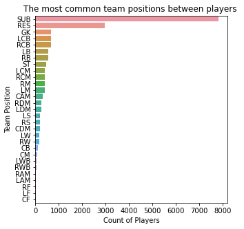

```python
#Histogram of positions of players
positions = data['team_position'].value_counts()
positions_order = positions.index
ax = plt.subplots(1,1, figsize=(5,5))

base_color = sb.color_palette()[0]
sb.countplot(data = data, y = 'team_position', order = positions_order)
plt.xlabel('Count of Players');
plt.ylabel('Team Position')
plt.title('The most common team positions between players ')
```

Most of the plyaers play in the SUB and RES positions

What is the shape of the distribution of ages of players ?

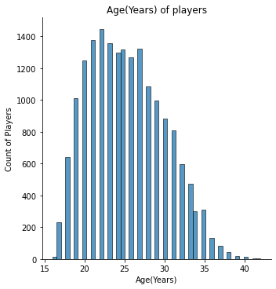

```python
#histogram of  age of players
sb.displot(data['age'])
plt.title('Age(Years) of players')
plt.xlabel('Age(Years)')
plt.ylabel('Count of Players');
```

Age 's distribution is slightly positively skewed. This support the initial finding of mean is greater than median and median greater than the mode.

What is the shape of the distribution of height of players ?

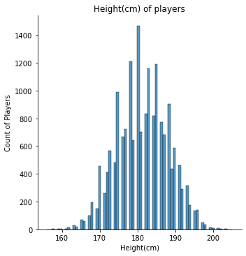

```python
#histogram of  height of players
sb.displot(data['height_cm'])
plt.title('Height(cm) of players')
plt.xlabel('Height(cm)')
plt.ylabel('Count of Players');
```

Hieght's distributions is normal and supports the finding of the mentioned descriptive statistics above.

What is the shape of the distribution of weight of players ?

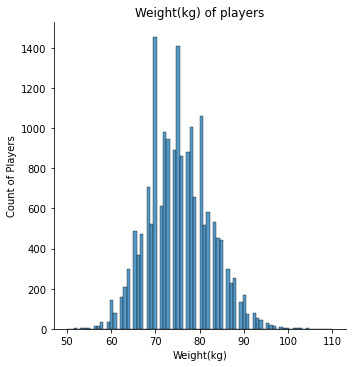

```python
#histogram of  weight of players
sb.displot(data['weight_kg'])
plt.title('Weight(kg) of players')
plt.xlabel('Weight(kg)')
plt.ylabel('Count of Players');
```

Wieght's distributions is normal and supports the finding of the mentioned descriptive statistics above.

What is the shape of the distribution of potential of players ?

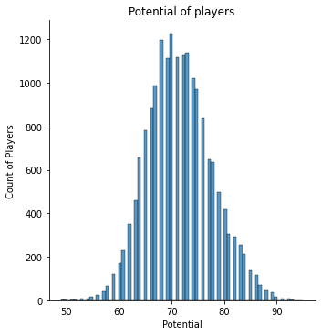

```python
#histogram of potential of players

sb.displot(data['potential'])
plt.title('Potential of players')
plt.xlabel('Potential')
plt.ylabel('Count of Players');
```

Potential's distributions is normal and supports the finding of the mentioned descriptive statistics above.

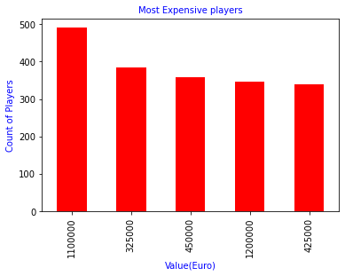

```python
#Let's have a look at the top 5 valued-palyers:
Value_Euro = data.value_eur.value_counts()[0:5]

g_bar = Value_Euro.plot.bar(color = 'red', fontsize = 10)

plt.title('Most Expensive players', color = 'blue', fontsize = '10')
plt.xlabel('Value(Euro)', color = 'blue', fontsize = '10')
plt.ylabel('Count of Players', color = 'blue', fontsize = '10');
```

The difference in the numbers of players for each value is small but the difference in the players values is considerably high

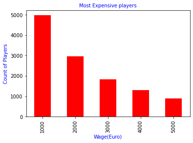

```python
#Let's have a look at the top 5 waged-palyers:
Wage_Euro = data.wage_eur.value_counts()[0:5]

g_bar = Wage_Euro.plot.bar(color = 'red', fontsize = 10)

#figure size(width, height)
#g_bar.figure.set_size_inches(5, 5);


plt.title('Most Expensive players', color = 'blue', fontsize = '10')
plt.xlabel('Wage(Euro)', color = 'blue', fontsize = '10')
plt.ylabel('Count of Players', color = 'blue', fontsize = '10');
```

The difference in the numbers of players for each value and the difference in the players wages is considerably high

What is the shape of the distribution of international reputation of players ?

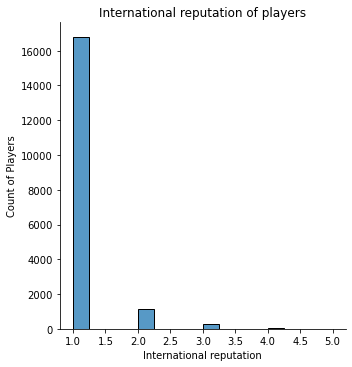

```python
#histogram of international reputation of players
sb.displot(data['international_reputation'])
plt.title('International reputation of players')
plt.xlabel('International reputation')
plt.ylabel('Count of Players');
```

Most of the players have the same international reputation(So no need for extra study on this factor)

### Discuss the distribution(s) of your variable(s) of interest. Were there any unusual points? Did you need to perform any transformations?

#### Basic Factors

- Weight, hieght and potential distributions are normal.All of these distributions support the findings of the descriptive statistics analysis done in the first section
- Age 's distribution is slightly positively skewed. This support the initial finding of mean is greater than median and median greater than the mode.

## Bivariate Exploration

Let's have a look at correlations

What is the relationship between player's position and Value(Euro) ?

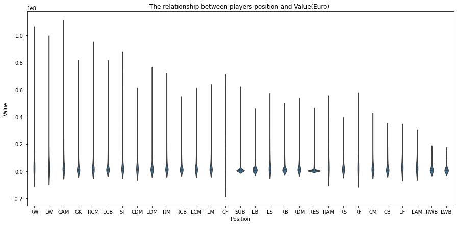

```python
#Violinplot for the relationship between player's position and Value(Euro)
ax = plt.subplots(1,1, figsize=(15,7))


sb.violinplot(data = data, x = 'team_position', y = 'value_eur',
             color = base_color,
              inner='quartile')
plt.ylabel('Value')
plt.xlabel('Position');
plt.title('The relationship between players position and Value(Euro) ')
```

What is the relationship between player's potential and Value (Euro) ?

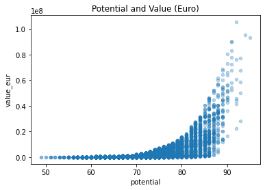

```python
# Correlation between Potential and Value (Euro)
data.plot(x='potential', y='value_eur',kind='scatter',alpha=0.3, title = 'Potential and Value (Euro)');
```

There is a clear positive(exponential) relationship between potential and value.

What is the relationship between player's age and Value (Euro) ?

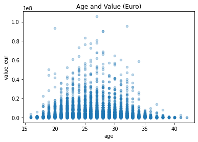

```python
# Correlation between Age and Value (Euro)
data.plot(x='age', y='value_eur', kind='scatter',alpha=0.3, title = 'Age and Value (Euro)');
```

There is optimum margin of Age to get high value

What is the relationship between player's height and Value (Euro) ?

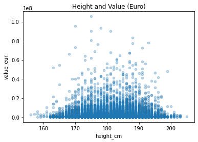

```python
# Correlation between Height and Value (Euro)
data.plot(x='height_cm', y='value_eur', kind='scatter',alpha=0.3, title = 'Height and Value (Euro)');
```

There is optimum margin of height to get high value

What is the relationship between player's weight and Value (Euro) ?

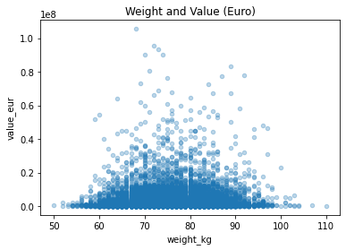

```python
# Correlation between Weight and Value (Euro)
data.plot(x='weight_kg', y='value_eur', kind='scatter',alpha=0.3, title = 'Weight and Value (Euro)');
```

There is optimum margin of weight to get high value

What are the relationships between player's age,height,weight, and Value (Euro) ?

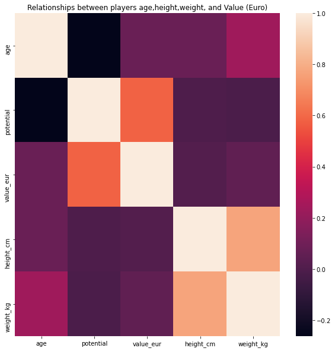

```python
data_hist = data[['age','potential', 'value_eur','height_cm', 'weight_kg']]

# plotting heatmap
f, ax = plt.subplots(figsize=(10, 10))
new_cor = data_hist.corr()
sb.heatmap(new_cor,
            yticklabels=new_cor.columns.values, xticklabels=new_cor.columns.values,
           );
plt.title('Relationships between players age,height,weight, and Value (Euro)');
```

This heatmap shows additional findings: 1.There is a positive correlation between weight and height.

1. There is a negative correlation between age and potential.

## Multivariate Exploration

What are the relationships between player's weight, age and body type ?

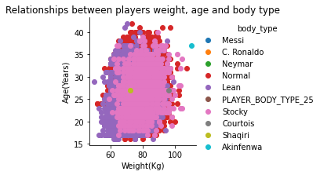

```python
# plotting facet
MLEXP1 = sb.FacetGrid(data = data, hue = 'body_type')
MLEXP1 .map(plt.scatter, 'weight_kg', 'age')
MLEXP1 .add_legend();
plt.title('Relationships between players weight, age and body type');
plt.xlabel('Weight(Kg)');
plt.ylabel('Age(Years)');
```

Most of the younger players have less weighs and more of a lean body type.

What are the relationships between player's value, age and work rate ?

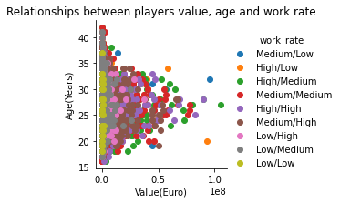

```python
# plotting facet
MLEXP1 = sb.FacetGrid(data = data, hue = 'work_rate')
MLEXP1 .map(plt.scatter, 'value_eur', 'age')
MLEXP1 .add_legend();
plt.title('Relationships between players value, age and work rate');
plt.xlabel('Value(Euro)');
plt.ylabel('Age(Years)');
```

The increase of value within suitable age margin results in higher work rate

What are the relationships between player's acceleration, age and work rate ?

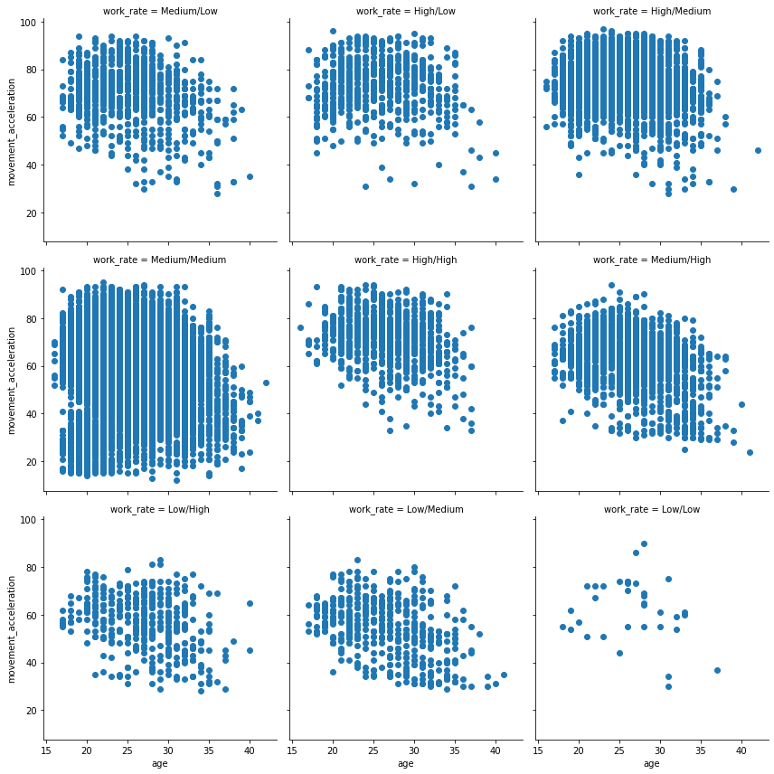

```python
# plotting facet
g = sb.FacetGrid(data = data, col = 'work_rate', col_wrap = 3, height = 4)
g.map(plt.scatter, 'age', 'movement_acceleration');
```

What is the relationship between player's weight and age ?

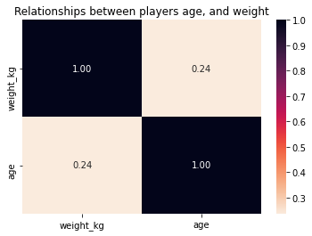

```python
weight_age = ['weight_kg', 'age']

# plotting heatmap
sb.heatmap(data[weight_age].corr(), cmap = 'rocket_r', annot = True, fmt = '.2f');
plt.title('Relationships between players age, and weight');
```

### Talk about some of the relationships you observed in this part of the investigation. Were there features that strengthened each other in terms of looking at your feature(s) of interest?

I decided to study further the relationship between age,weight on one side and the body type on the other side which gave a logical result of Most of the younger players have less weighs and more of a lean body type.